# The Neural Vault

How to Build a Second Brain with Obsidian and AI

Abdullah

2026-04-10

## Motivation

**Every time you open a new AI chat, it starts from scratch. I built a fix.**

- **The Problem**: You spend the first ten minutes re-explaining your project, your preferences, your decisions. The session ends. Next time, you do it all again. The model is smart — but it has no memory.
- **Why not enterprise tools?** Solutions like RAG exist, but they require a learning curve, ongoing costs, and debugging skills most individuals don’t need. You wouldn’t rent a warehouse to store a notebook.
- **The Spark**: A conversation with Professor Vincent about markdown note-taking — three months ago — sent me down a rabbit hole. I went home that night and started building.
- **The Result**: The **Neural Vault** — a structured Obsidian vault that gives the AI persistent context. No database. No infrastructure. Just markdown files and a simple workflow.

## The Obsidian Brain Preview

**Your knowledge, connected and readable by both you and the AI.**

- **Inbox**: Raw capture — quick, unorganized thoughts.
- **Wiki**: Structured knowledge the AI helped you write.
- **Archive**: Deprecated notes, kept for history.
- **Agent Sandbox**: A messy workspace for AI agents — kept separate so your vault stays clean.

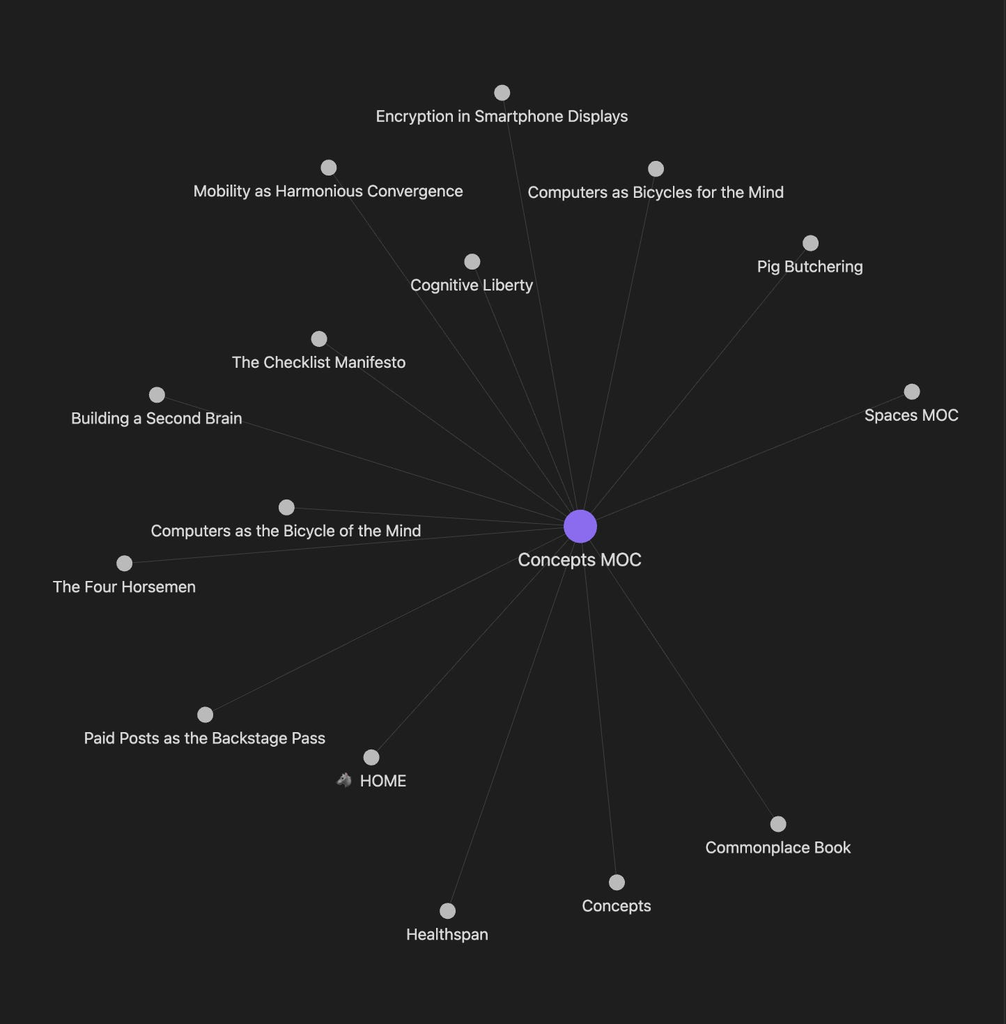